# Alberta Income Support: Historic Caseload Trends

Answering two research questions from 20 years of monthly ALSS data

Author

Literate analysis — GitHub Copilot (Grok Code Fast 1)

Published

April 1, 2026

## Research Questions

This document is a reproducible, literate analysis of the Alberta Income Support caseload dataset. It directly addresses two questions:

1. **What is the historic trend of Income Support caseload?**
2. **How does breaking it down by BFE and ETW change the story?**

## Data Source

The data comes from the Alberta Open Government portal, specifically the “Income Support Aggregated Caseload Data” dataset. It covers April 2005 to September 2025, with monthly observations.

Key details: - **File**: `is-aggregated-data-april-2005-sep-2025.csv` - **Rows**: 3,722 data rows - **Geography**: Province of Alberta - **Measure Types**: Total Caseload, Client Type Level (BFE and ETW breakdowns from 2012)

## Data Ingestion and Cleaning

```r
# Read the CSV, skipping the first header row
data <- read_csv("../../is-aggregated-data-april-2005-sep-2025.csv",
                 skip = 1,
                 col_names = c("Ref_Date", "Geography", "Measure_Type", "Measure", "Value", rep("", 9)),
                 show_col_types = FALSE)

# Clean the Value column: remove spaces and commas, convert to numeric
data <- data %>%
  mutate(Value = as.numeric(gsub("[ ,]", "", Value)))

# Parse dates: Ref_Date is in "YY-Mon" format, e.g., "05-Apr" -> 2005-04-01
data <- data %>%
  mutate(Date = parse_date_time(Ref_Date, "ym"))

# Select relevant columns
data <- data %>%
  select(Date, Measure_Type, Measure, Value)

# Preview the data
head(data)
```

| Date | Measure_Type | Measure | Value |
| --- | --- | --- | --- |
|  | Measure Type | Measure | NA |
| 2005-04-01 | Total Caseload | Total Caseload | 27969 |
| 2005-05-01 | Total Caseload | Total Caseload | 27894 |
| 2005-06-01 | Total Caseload | Total Caseload | 27720 |
| 2005-07-01 | Total Caseload | Total Caseload | 27680 |
| 2005-08-01 | Total Caseload | Total Caseload | 27702 |

## Overall Caseload Trend

First, let’s examine the total Income Support caseload over time.

[figure not shown]

```r
total_caseload <- data %>%
  filter(Measure_Type == "Total Caseload") %>%
  arrange(Date)

ggplot(total_caseload, aes(x = Date, y = Value)) +
  geom_line(color = "blue") +
  labs(title = "Alberta Income Support Total Caseload (2005-2025)",
       x = "Date",
       y = "Caseload") +
  scale_y_continuous(labels = comma) +
  theme_minimal()
```

The total caseload shows fluctuations over the years, with notable peaks and troughs.

## Breakdown by Client Type (BFE and ETW)

From April 2012, the data includes breakdowns by client type: Barriers to Full Employment (BFE) and Expected to Work (ETW).

ETW is further subdivided into Working, Not Working (Available), and Not Working (Unavailable). For this analysis, we’ll aggregate ETW into a total.

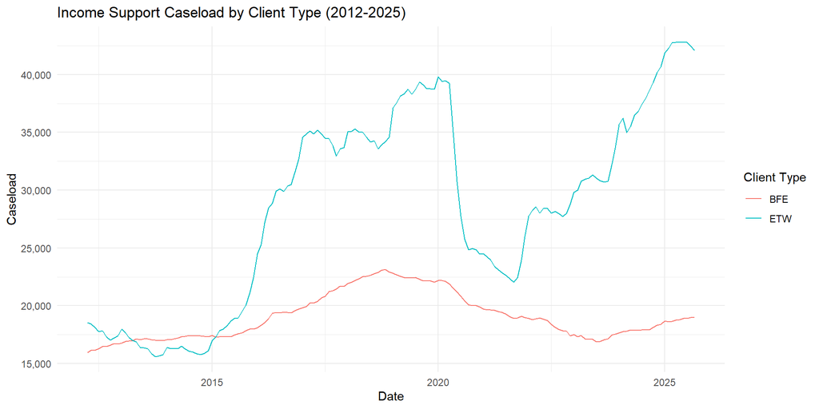

```r
# Filter for Client Type Level data from 2012 onwards
client_data <- data %>%
  filter(Measure_Type == "Client Type Level",
         Date >= as.Date("2012-04-01")) %>%
  mutate(Client_Type = case_when(
    Measure == "BFE - Total" ~ "BFE",
    grepl("^ETW", Measure) ~ "ETW",
    TRUE ~ "Other"
  )) %>%
  filter(Client_Type != "Other") %>%
  group_by(Date, Client_Type) %>%
  summarise(Value = sum(Value), .groups = "drop")

# Plot the breakdown
ggplot(client_data, aes(x = Date, y = Value, color = Client_Type)) +
  geom_line() +
  labs(title = "Income Support Caseload by Client Type (2012-2025)",
       x = "Date",
       y = "Caseload",
       color = "Client Type") +
  scale_y_continuous(labels = comma) +
  theme_minimal()
```

Breaking down by BFE and ETW reveals different trends. BFE (clients with barriers) and ETW (clients expected to work) show distinct patterns over time.

## Comparative Analysis

To see how the breakdown changes the story, let’s compare the total caseload with the sum of BFE and ETW.

[figure not shown]

```r
# Calculate total from breakdown
breakdown_total <- client_data %>%
  group_by(Date) %>%
  summarise(Breakdown_Total = sum(Value))

# Combine with overall total
comparison <- total_caseload %>%
  filter(Date >= as.Date("2012-04-01")) %>%
  left_join(breakdown_total, by = "Date") %>%
  pivot_longer(cols = c(Value, Breakdown_Total), names_to = "Source", values_to = "Caseload") %>%
  mutate(Source = recode(Source, "Value" = "Total Caseload", "Breakdown_Total" = "BFE + ETW"))

ggplot(comparison, aes(x = Date, y = Caseload, color = Source)) +
  geom_line() +
  labs(title = "Comparison: Total Caseload vs. BFE + ETW Sum (2012-2025)",
       x = "Date",
       y = "Caseload") +
  scale_y_continuous(labels = comma) +
  theme_minimal()
```

## Proportions Over Time

Let’s examine the proportion of BFE vs ETW over time.

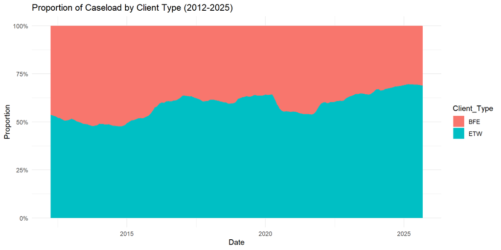

```r
proportions <- client_data %>%
  group_by(Date) %>%
  mutate(Proportion = Value / sum(Value)) %>%
  ungroup()

ggplot(proportions, aes(x = Date, y = Proportion, fill = Client_Type)) +
  geom_area() +
  labs(title = "Proportion of Caseload by Client Type (2012-2025)",
       x = "Date",
       y = "Proportion") +
  scale_y_continuous(labels = percent) +
  theme_minimal()
```

This area chart shows how the composition of the caseload has changed over time between BFE and ETW clients.